# Real-world Data Wrangling

```python
!python -m pip install kaggle==1.6.12
```

```python
!pip install --target=/workspace ucimlrepo
```

# Problem Statement

## Are multi-disciplined professional cyclists more successful than single discipline cyclists?

**UCI cycling data is generally difficult to acquire, especially for projects such as this one. Luckily I have managed to track down two of the cleaner datasets that are available. However the data is more complete for the male riders than the female rider as a result of this, I will remove the female related data.**

```python
import pandas as pd
import numpy as np
import requests as rq
import opendatasets as od
import matplotlib.pyplot as plt
import seaborn as sns
import warnings


warnings.filterwarnings("ignore", category=FutureWarning)
```

## 1. Gather data

### The first file

#### **Dataset 1**

Type: .csv file

Method: This .csv was downloaded directly from: https://data.mendeley.com/datasets/mkzht8948x/2

Dataset variables:

#### Breakdown

'sport' is broken down by 8 overall categories: 'mountain-bike', 'trials', 'bmx-freestyle', 'bmx-racing', 'indoor', 'cyclo-cross', 'road' and 'track'

'discipline' are sub-categories of 'sport': 'Cross-country short circuit', 'Cross-country Olympic', 'Enduro', 'Downhill', 'Cross-country marathon', 'Cross-country eliminator', 'E-MTB Enduro', '4X', '20-inch Wheel Size', '26-inch Wheel Size', 'Open', 'E-MTB Cross-country', 'Cross-country team relay', 'Pump Track', 'Cross-country Olympic Junior Series', 'E-MTB Cross-Country Marathon', 'Park', 'Flatland', 'Individual', 'Artistic Cycling ACT4', 'Pair Artistic Cycling Women', 'Pair Artistic Cycling Mix', 'Single Artistic Cycling Men', 'Single Artistic Cycling Women', 'Cycle-ball', 'Individual Road Race', 'Individual Time Trial', 'Team Time Trial', 'Individual Pursuit', 'Keirin', 'Time Trial', 'Team Sprint', 'Scratch', 'Sprint', 'Team Pursuit', 'Madison', 'Omnium', 'Points Race', 'Elimination Race', 'Cross-country marathon Series', 'Cross-country stage races', 'Cross-country point-to-point', 'Team time trial mixed relay' and 'Olympic Sprint'

'classification' contains codes that are used by the UCI to describe the races, some are somewhat self-explanatory, e.g. '1.WWT - 1 day - UCI Women’s WorldTour' while others would require some knowledge and pairing with other column values e.g. 'CL3 - Class 3'. For this analysis we won’t need this column

‘competition’ contains the actual names of the races e.g. Tour de France, UCI BMX Supercross World Cup etc.

‘location’ contains an abbreviated code for the host nation for each race. E.g. ITA, FRA, GBR etc.

‘jr_u23_elite_masters’ references the age categories for each race:

‘Elite’, ‘Junior’, ‘Masters’ and ‘Under 23’ We will focus on the ‘Elites’ groups, as these are more representative of the current professional roster

‘year’ is the year of each race

‘class_code’ is a UCI code system that works as an numerical identifier for the 'classification' column

‘rank’ is the position the rider finished in the race

‘fullname’ is the full name of each rider

‘last_name’ is the surname of each rider

‘first_name’ is the first name of each rider

‘country’ contains an abbreviated code for rider. E.g. ITA, FRA, GBR etc.

‘team’ the team names, were applicable, for each rider. Note:- Team names can change over time, especially in terms of sponsorship. E.g. ‘Lotto NL Jumbo’ became ‘JUMBO-VISMA’

‘gender’ is split between ‘F’ and ‘M’

‘age’ is the age of each rider

‘result’ contains the finishing time information for each race/stage

'points' refer to the number of UCI points earned per stage/race that impact the riders world ranking

```python
#FILL IN 1st data gathering and loading method

data_file1 = pd.read_csv('UCI/results_2021_10_08.csv',  delimiter=';')
df1 = data_file1.copy()
df1.head()
```

|  | sport | discipline | classification | competition | location | jr_u23_elite_masters | year | class_code | rank | fullname | last_name | first_name | country | team | gender | age | result | points |
| --- | --- | --- | --- | --- | --- | --- | --- | --- | --- | --- | --- | --- | --- | --- | --- | --- | --- | --- |
| 0 | mountain-bike | Cross-country short circuit | 3 - Class 3 | Karl XII rittet | NOR | Elite | 2021 | 3.0 | 1 | Erik HÆGSTAD | HÆGSTAD | Erik | NOR | NaN | M | 25.0 | 34:00 | 10,00 |
| 1 | mountain-bike | Cross-country short circuit | 3 - Class 3 | Karl XII rittet | NOR | Elite | 2021 | 3.0 | 2 | Ole Sigurd REKDAHL | REKDAHL | Ole Sigurd | NOR | NaN | M | 20.0 | 34:54 | 6,00 |
| 2 | mountain-bike | Cross-country short circuit | 3 - Class 3 | Karl XII rittet | NOR | Elite | 2021 | 3.0 | 3 | Knut RØHME | RØHME | Knut | NOR | NaN | M | 22.0 | 34:57 | 4,00 |
| 3 | mountain-bike | Cross-country short circuit | 3 - Class 3 | Karl XII rittet | NOR | Elite | 2021 | 3.0 | 4 | Mats Tubaas GLENDE | GLENDE | Mats Tubaas | NOR | NaN | M | 22.0 | 35:09 | 2,00 |
| 4 | mountain-bike | Cross-country short circuit | 3 - Class 3 | Karl XII rittet | NOR | Elite | 2021 | 3.0 | 5 | André ERIKSSON | ERIKSSON | André | SWE | NaN | M | 20.0 | 36:17 | 1,00 |

```python
df1.info()
```

```
<class 'pandas.core.frame.DataFrame'>
RangeIndex: 4466832 entries, 0 to 4466831
Data columns (total 18 columns):
 #   Column                Dtype
---  ------                -----
 0   sport                 object
 1   discipline            object
 2   classification        object
 3   competition           object
 4   location              object
 5   jr_u23_elite_masters  object
 6   year                  int64
 7   class_code            float64
 8   rank                  int64
 9   fullname              object
 10  last_name             object
 11  first_name            object
 12  country               object
 13  team                  object
 14  gender                object
 15  age                   float64
 16  result                object
 17  points                object
dtypes: float64(2), int64(2), object(14)
memory usage: 613.4+ MB
```

## The Second File

#### Dataset 2

Type: .csv

Method: Programatically from Kaggle. Username and API "Kaggle Key is required"

Source: https://www.kaggle.com/datasets/fewinder/uci-pro-road-cycling-dataset

**The second file contains more, what could be described as 'bio' and team data for the riders**

**Dataset variables:**

**Year - The year that the rider was with their team**

**Function - This refers to the role that the rider would hold im this particular datasets Note: there is only one role "Rider. However this is more nuanced as rider could have many other roles in the team, "Team Leader" or "Domesituqe" (helper), however this dataset does not contain this information.**

**Last Name - The riders surname**

**First Name - The riders first name**

**Birth date - The riders date of birth in the international format - d/m/y**

**Birth date US - The riders date of birth in the US format - m/d/y**

**Age - The riders age at the time of the creation of this dataset**

**Gender - The riders given gender at the time of the creation of this dataset**

**Category - This is abbreviated description of each riders team, usually split between WTT (World Tour Team) and a variations of "Continental Teams", sometimes split by gender: CTM - Continental Team Men, CTM - Continental Team Women**

**Country - The country that the rider is from**

**Continent - The continent that the rider is from**

**Team Code - This is abbreviated description of each riders team name**

**Team Name - The full version of the team name**

**UCIID - The ID given to each rider by the governing body: Union Cycliste Internationale (UCI)**

```python
#FILL IN 2nd data gathering and loading method

od.download('https://www.kaggle.com/datasets/fewinder/uci-pro-road-cycling-dataset')
```

```
Skipping, found downloaded files in ".\uci-pro-road-cycling-dataset" (use force=True to force download)
```

```python
file = ('uci-pro-road-cycling-dataset/UCIRiders0519_2x.csv')
data_file2 = pd.read_csv(file)
df2 = data_file2.copy()
df2.head()
```

|  | Year | Function | Last Name | First Name | Birth date | Birth date US | Age | Gender | Category | Country | Continent | Team Code | Team Name | UCIID |
| --- | --- | --- | --- | --- | --- | --- | --- | --- | --- | --- | --- | --- | --- | --- |
| 0 | 2014 | Rider | GARNEAU | Louis | 09/08/1958 | 8/9/1958 | 56 | Male | CTM | CAN | AME | GQC | GARNEAU - QUÉBECOR | 10008746249 |
| 1 | 2013 | Rider | GARNEAU | Louis | 09/08/1958 | 8/9/1958 | 55 | Male | CTM | CAN | AME | GQC | EQUIPE GARNEAU - QUÉBECOR | 10008746249 |
| 2 | 2019 | Rider | PITEL | Edwige | 04/06/1967 | 6/4/1967 | 52 | Female | CTW | FRA | EUR | CGS | COGEAS METTLER LOOK PRO CYCLING TEAM | 10002663541 |
| 3 | 2018 | Rider | NEDERLOF | Lex | 10/06/1966 | 6/10/1966 | 52 | Male | CTM | NED | EUR | CCN | NEX CCN CYCLING TEAM | 10073852346 |
| 4 | 2018 | Rider | PITEL | Edwige | 04/06/1967 | 6/4/1967 | 51 | Female | CTW | FRA | EUR | CGS | COGEAS - METTLER PRO CYCLING TEAM | 10002663541 |

```python
df2.info()
```

```
<class 'pandas.core.frame.DataFrame'>
RangeIndex: 47442 entries, 0 to 47441
Data columns (total 14 columns):
 #   Column         Non-Null Count  Dtype
---  ------         --------------  -----
 0   Year           47442 non-null  int64
 1   Function       47442 non-null  object
 2   Last Name      47441 non-null  object
 3   First Name     47442 non-null  object
 4   Birth date     47442 non-null  object
 5   Birth date US  47442 non-null  object
 6   Age            47442 non-null  int64
 7   Gender         47442 non-null  object
 8   Category       47442 non-null  object
 9   Country        47442 non-null  object
 10  Continent      47442 non-null  object
 11  Team Code      47442 non-null  object
 12  Team Name      47442 non-null  object
 13  UCIID          47442 non-null  int64
dtypes: int64(3), object(11)
memory usage: 5.1+ MB
```

## 2. Assess data

Assess the data according to data quality and tidiness metrics using the report below.

List **two** data quality issues and **two** tidiness issues. Assess each data issue visually **and** programmatically, then briefly describe the issue you find. **Make sure you include justifications for the methods you use for the assessment.**

### Tidiness Issue for the 1st file:

**There is an issue with some of the race names, in particular the "Grand Tour" (La Vuelta ciclista a España) and** **the multi-stage races 'Paris-Nice' and 'Tirreno-Adriatico'**

**The Spanish grand tour (La Vuelta ciclista a España) was once called "Vuelta a España", both names have been recorded in** **this dataset, it gives the impression that they are two different races.**

**The function below will produce a visualization of the problem**

#### Function depository

```python
def mens_races_by_location(location):
    """
    Plots the number of races for a given location where classification is '2.UWT - Stages - UCI WorldTour'.

    Parameters:
    location (str): The location to filter the races (e.g., 'ESP', 'ITA', 'GBR').
    """
    # Filter the data for the specific conditions
    filtered_df = df1[(df1['location'] == location) & (df1['classification'] == '2.UWT - Stages - UCI WorldTour')]

    # Count the number of races per competition
    competition_counts = filtered_df['competition'].value_counts()

    # Create a bar chart
    plt.figure(figsize=(10, 6))
    competition_counts.plot(kind='bar', color='skyblue')
    plt.title(f'Number of Races in {location} with Classification 2.UWT - Stages - UCI WorldTour')
    plt.xlabel('Competition')
    plt.ylabel('Number of Races')
    plt.xticks(rotation=45, ha='right')
    plt.tight_layout()

    # Show the plot
    plt.show()
```

#### Visualising the naming issues for some of the races

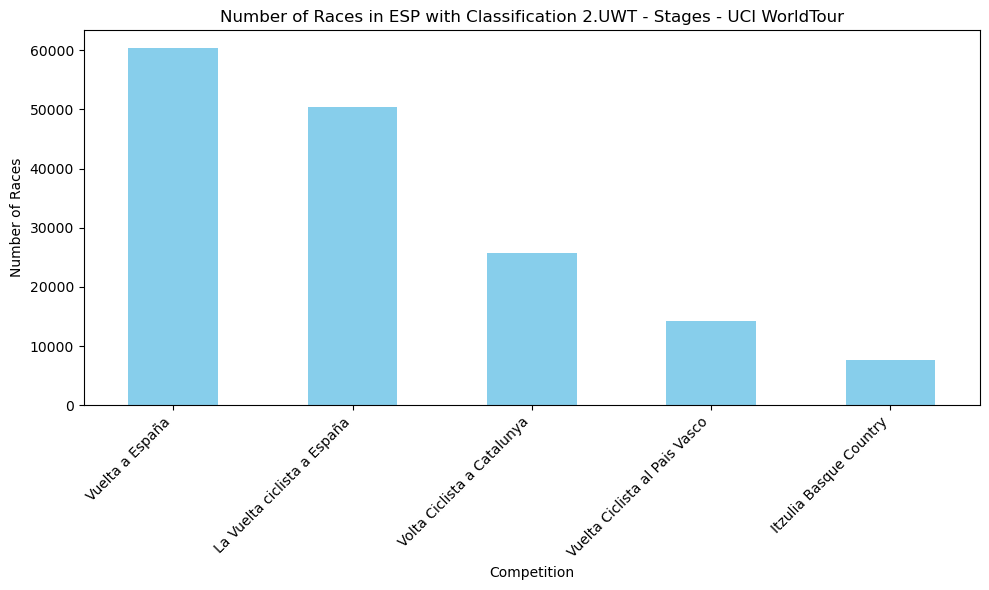

```python
#FILL IN - Inspecting the dataframe visually
mens_races_by_location('ESP')
```

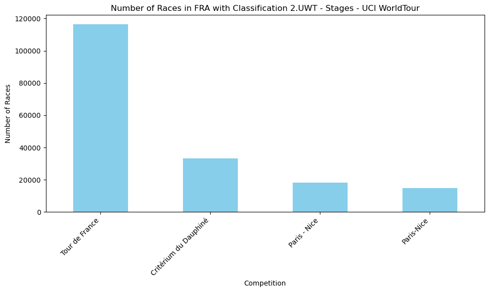

```python
mens_races_by_location('FRA')
```

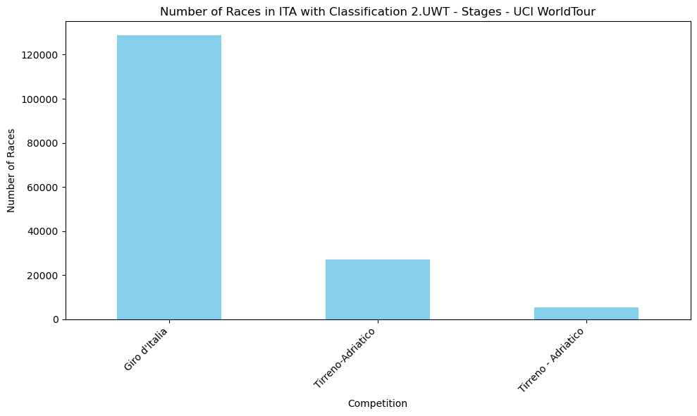

```python
mens_races_by_location('ITA')
```

```python
#FILL IN - Inspecting the dataframe programmatically

races = 'Nice|Tirreno|a España'
df1.loc[df1['competition'].str.contains(races), 'competition'].unique()
```

```
array(['La Vuelta ciclista a España', 'Tirreno-Adriatico', 'Paris-Nice',
       'Vuelta a España', 'Tirreno - Adriatico', 'Paris - Nice'],
      dtype=object)
```

```python
#FILL IN - Apply the cleaning strategy


correct_names = {'Vuelta a España':'La Vuelta ciclista a España', 'Paris-Nice':'Paris - Nice',
                 'Tirreno - Adriatico':'Tirreno-Adriatico'}
df1 = df1.replace(correct_names).copy()
```

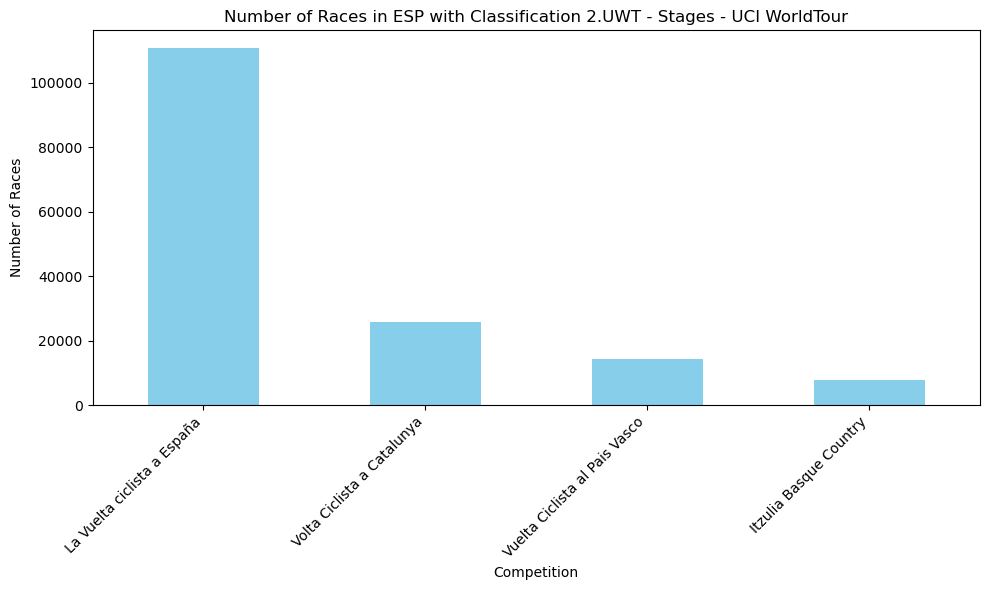

```python
#FILL IN - Validate the cleaning was successful

mens_races_by_location('ESP')
```

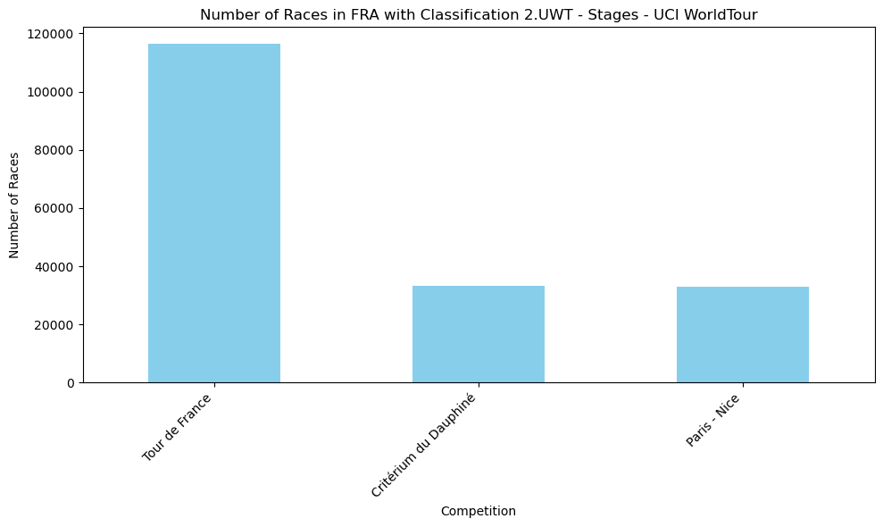

```python
mens_races_by_location('FRA')
```

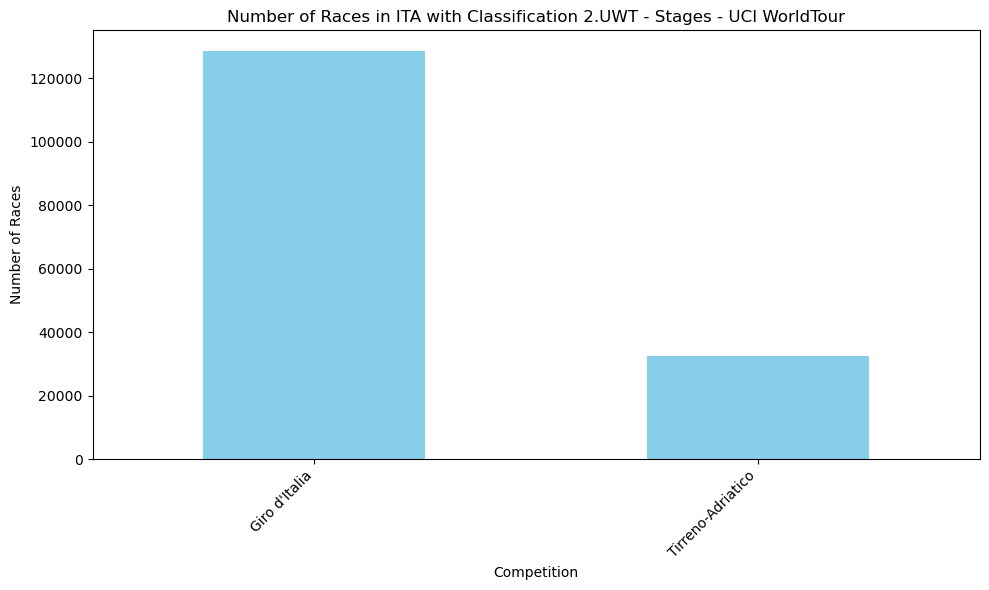

```python
mens_races_by_location('ITA')
```

Justification: **By cleaning these columns eliminates the change of cyclists being recorded multiple times for the differently but the same race**

## Quality issue - File 1

**Given that the dataset contains different cycling disciplines, the 'result' column will have a mixture of times (recorded in different formats e.g. "+5.00") 'DSQ' (Disqualified), 'DNF' (Did Not Finish), 'DNS' (Did Not Start) 'LAP' and NaN.**

**The name of the column 'result' may or may not cause confusion because it refers to the time (in some cases) result of the race/stage. Whereas 'rank' refers to the overall position that the rider finished, 1st, 32nd etc.** **This means that any single rider can have multiple entries, but not actually duplicates**

**Using the graph below, we can see how this mixture of results will impact validity of the analysis**

```
''
```

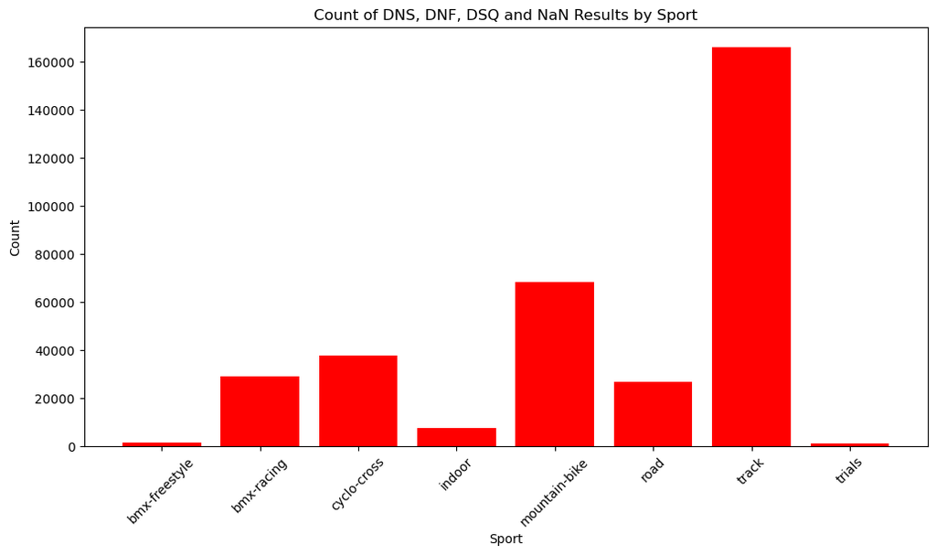

```python
#FILL IN - Inspecting the dataframe visually


# Filter and group the data
result_counts = df1[(df1['result'].isna()) | (df1['result'].isin(['DNS', 'DNF', 'DSQ', 'LAP', 'NaN']))].groupby('sport').size()

# Convert the Series to a DataFrame for plotting
result_counts_df = result_counts.reset_index(name='count')

# Plotting the bar graph
plt.figure(figsize=(12, 6))
plt.bar(result_counts_df['sport'], result_counts_df['count'], color='red')

# Adding titles and labels
plt.title('Count of DNS, DNF, DSQ and NaN Results by Sport')
plt.xlabel('Sport')
plt.ylabel('Count')

# Rotating x-axis labels for better readability
plt.xticks(rotation=45)
;
```

### Programmatic visual of the issue

**Using the code lines below, shows a more granular view at the issues, such as times recorded in different ways, "DNF"/"DNS"/DSQ"**

```python
#FILL IN - Inspecting the dataframe programmatically

df1[['sport', 'discipline','competition', 'location',
       'jr_u23_elite_masters', 'year','rank', 'fullname','result',
       'points']].sample(random_state=4)
```

|  | sport | discipline | competition | location | jr_u23_elite_masters | year | rank | fullname | result | points |
| --- | --- | --- | --- | --- | --- | --- | --- | --- | --- | --- |
| 3477641 | road | Individual Road Race | Premondiale Giro Toscana Int. Femminile - Memo... | ITA | Elite | 2012 | 22 | Jennifer FIORI | +5:00 | NaN |

```python
df1[['sport', 'discipline','competition', 'location',
       'jr_u23_elite_masters', 'year','rank', 'fullname','result',
       'points']].sample(random_state=120)
```

|  | sport | discipline | competition | location | jr_u23_elite_masters | year | rank | fullname | result | points |
| --- | --- | --- | --- | --- | --- | --- | --- | --- | --- | --- |
| 1124460 | road | Individual Road Race | Tour de Slovaquie | SVK | Elite | 2018 | 10 | Johannes SCHINNAGEL | 02'05'' | NaN |

```python
df1.loc[df1['result'] == 'DNF'].sample(3)
```

|  | sport | discipline | classification | competition | location | jr_u23_elite_masters | year | class_code | rank | fullname | last_name | first_name | country | team | gender | age | result | points |
| --- | --- | --- | --- | --- | --- | --- | --- | --- | --- | --- | --- | --- | --- | --- | --- | --- | --- | --- |
| 1910954 | road | Individual Road Race | 1.2 - 1 day - Class 2 | GP Laguna Porec | CRO | Elite | 2017 | 12.0 | 141 | Dániel MÓRICZ | MÓRICZ | Dániel | HUN | NaN | M | 25.0 | DNF | NaN |
| 2721099 | track | Points Race | CL3 - Class 3 | U.S. Vic Williams Memorial Grand Prix | USA | Elite | 2015 | 3.0 | 99 | Thomson REMO | REMO | Thomson | USA | NaN | M | 29.0 | DNF | 1,00 |
| 1066247 | bmx-racing | Individual | C1 - Class 1 | Copa Latinoamericana - Round 4 | COL | Elite | 2018 | 1.0 | 15 | Yolmer Andres MURILLO VALENCIA | MURILLO VALENCIA | Yolmer Andres | COL | NaN | M | 24.0 | DNF | NaN |

```python
df1.loc[df1['result'] == 'DNS'].sample(3)
```

|  | sport | discipline | classification | competition | location | jr_u23_elite_masters | year | class_code | rank | fullname | last_name | first_name | country | team | gender | age | result | points |
| --- | --- | --- | --- | --- | --- | --- | --- | --- | --- | --- | --- | --- | --- | --- | --- | --- | --- | --- |
| 1522000 | mountain-bike | Downhill | CN - National Championships | Slovak National Championships - DHI | SVK | Elite | 2017 | NaN | 17 | Jozef ONDIC | ONDIC | Jozef | SVK | KELLYS FACTORY TEAM | M | 25.0 | DNS | NaN |
| 1046579 | mountain-bike | Cross-country Olympic Junior Series | 1 - Class 1 | Baie Saint Paul Coupe Canada XCO + UCI Junior ... | CAN | Junior | 2018 | 1.0 | 16 | Evelyne WARD | WARD | Evelyne | CAN | NaN | F | 20.0 | DNS | 10,00 |
| 1039262 | mountain-bike | Cross-country Olympic | 1 - Class 1 | Int. KitzAlpBike-Festival | AUT | Elite | 2018 | 1.0 | 49 | Arnis PETERSONS | PETERSONS | Arnis | LAT | ZZK | M | 27.0 | DNS | NaN |

```python
df1.loc[df1['result']== 'LAP'].sample(3)
```

|  | sport | discipline | classification | competition | location | jr_u23_elite_masters | year | class_code | rank | fullname | last_name | first_name | country | team | gender | age | result | points |
| --- | --- | --- | --- | --- | --- | --- | --- | --- | --- | --- | --- | --- | --- | --- | --- | --- | --- | --- |
| 1055236 | mountain-bike | Cross-country Olympic | HC - Hors Class | US Cup - Bonelli Park XCO + UCI Junior Series XCO | USA | Elite | 2018 | NaN | 72 | Trevor MCCUTCHEON | MCCUTCHEON | Trevor | USA | NaN | M | 22.0 | LAP | NaN |
| 11119 | mountain-bike | Cross-country Olympic | 2 - Class 2 | 3 Nations Cup - Op Fietse MTB | NED | Elite | 2021 | 2.0 | 32 | Elio CLARYSSE | CLARYSSE | Elio | BEL | NaN | M | 19.0 | LAP | NaN |
| 1519774 | mountain-bike | Cross-country Olympic | 1 - Class 1 | Coupe de France XCO # 5 XCE # 4 DHI # 2 | FRA | Elite | 2017 | 1.0 | 124 | Lucas WINIGER | WINIGER | Lucas | FRA | VELO CLUB ORNANS | M | 25.0 | LAP | NaN |

```python
df1.loc[df1['result'].isna()].head(3)
```

|  | sport | discipline | classification | competition | location | jr_u23_elite_masters | year | class_code | rank | fullname | last_name | first_name | country | team | gender | age | result | points |
| --- | --- | --- | --- | --- | --- | --- | --- | --- | --- | --- | --- | --- | --- | --- | --- | --- | --- | --- |
| 506 | mountain-bike | Cross-country short circuit | CDM - World Cup | MERCEDES-BENZ UCI MTB WORLD CUP - XCO/XCC/DHI | SUI | Elite | 2021 | NaN | 33 | Sandra WALTER | WALTER | Sandra | CAN | NaN | F | 41.0 | NaN | NaN |
| 507 | mountain-bike | Cross-country short circuit | CDM - World Cup | MERCEDES-BENZ UCI MTB WORLD CUP - XCO/XCC/DHI | SUI | Elite | 2021 | NaN | 34 | Haley SMITH | SMITH | Haley | CAN | NaN | F | 28.0 | NaN | NaN |
| 508 | mountain-bike | Cross-country short circuit | CDM - World Cup | MERCEDES-BENZ UCI MTB WORLD CUP - XCO/XCC/DHI | SUI | Elite | 2021 | NaN | 35 | Githa MICHIELS | MICHIELS | Githa | BEL | NaN | F | 38.0 | NaN | NaN |

### Quality Resolutions for the first file

**Since this analysis will look at the success of multi-disciplined riders who also participate in road races vs those who participate solely in road racing I will:**

**Remove the "result" column as this has too many inconsistent variables as seen below**

**Keep the "DNS"/"DNF"/"DSQ", as this may assist in the overall analysis**

**Convert the dataset to one row per rider, thus removing multiple entries**

**Drop "age" column as I can use the more accurate birth date from the second file**

### Keeping things simple for df1

**To make things as clear as possible, I will split the races into the following columns**

**Giro d'Italia**

**Tour de France**

**La Vuelta ciclista a España**

**Stage Races**

**One-Day Races**

**National Championship Race**

**National Championship Time Trail**

**Continental Championship Race**

**Continental Championship Time Trail**

**World Championship Race**

**World Championship Time Trail**

**Olympic Road Race**

**Olmypic Time Trail**

**Furthermore: each of the race column will show a count of how many times each rider finished on the podium (1st, 2nd or 3rd), else 0**

**Where applicable. the number of road, mountain bike, cyclocross, indoor and track will be counted for each rider**

**Finally, the number of DNS (Did Not Start), DNF (Did Not Finish) and DSQ (Disqualified) will be counted for each rider**

```python
# FILL IN - Apply the cleaning strategy


# Creating helper columns for counting
df1['one_day_race'] = ((df1['classification'] == '1.UWT - 1 day - UCI WorldTour') & (df1['rank'].isin([1, 2, 3]))).astype(int)
df1["giro_d'italia"] = ((df1['competition'].str.contains("Giro d'Italia", case=False, na=False)) & (df1['rank'].isin([1, 2, 3]))).astype(int)
df1["tour_de_france"] = ((df1['competition'].str.contains("Tour de France", case=False, na=False)) & (df1['rank'].isin([1, 2, 3]))).astype(int)
df1["la_vuelta_ciclista_a_españa"] = ((df1['competition'].str.contains("La Vuelta ciclista a España", case=False, na=False)) &
                                      (df1['rank'].isin([1, 2, 3]))).astype(int)

# Creating a helper column for stage races
df1['stage_races'] = ((df1['classification'] == '2.UWT - Stages - UCI WorldTour') &
                      (~df1['competition'].str.contains("Giro d'Italia|Tour de France|La Vuelta ciclista a España",
                                                        case=False, na=False)) &
                      (df1['rank'].isin([1, 2, 3]))).astype(int)

# Creating binary columns for sports
df1['mountain_bike'] = (df1['sport'] == 'mountain-bike').astype(int)
df1['cyclo_cross'] = (df1['sport'] == 'cyclo-cross').astype(int)
df1['indoor'] = (df1['sport'] == 'indoor').astype(int)
df1['track'] = (df1['sport'] == 'track').astype(int)
df1['road'] = (df1['sport'] == 'road').astype(int)


# Creating columns that represent the riders current and former age classifications
df1['junior'] = df1['jr_u23_elite_masters'].str.contains('Junior', case=False, na=False)
df1['u_23'] = df1['jr_u23_elite_masters'].str.contains('U23', case=False, na=False)
df1['elite'] = df1['jr_u23_elite_masters'].str.contains('Elite', case=False, na=False)
df1['masters'] = df1['jr_u23_elite_masters'].str.contains('Masters', case=False, na=False)





# Creating columns that count the number of podium places for each competition
df1['individual_time_trial'] = ((df1['discipline'] == 'Individual Time Trial') & (df1['rank'].isin([1, 2, 3]))).astype(int)
df1['team_time_trial'] = ((df1['discipline'] == 'Team Time Trial') & (df1['rank'].isin([1, 2, 3]))).astype(int)
df1['team_time_trial_mixed_relay'] = ((df1['discipline'] == 'Team time trial mixed relay') & (df1['rank'].isin([1, 2, 3]))).astype(int)
df1['olympic'] = (df1['competition'].str.contains('Olympic', case=False, na=False) & (df1['rank'].isin([1, 2, 3]))).astype(int)
df1['world_championships'] = ((df1['classification'] == 'CM - UCI World Championships') & (df1['rank'].isin([1, 2, 3]))).astype(int)
df1['continental_championships'] = ((df1['classification'] == 'CC - Continental Championships') & (df1['rank'].isin([1, 2, 3]))).astype(int)
df1['national_championships'] = ((df1['classification'] == 'CN - National Championships') & (df1['rank'].isin([1, 2, 3]))).astype(int)

# Creating columns that count the number of races not finished/started/disqualified
df1['DSQ'] = (df1['result'] == 'DSQ').astype(int)
df1['DNF'] = (df1['result'] == 'DNF').astype(int)
df1['DNS'] = (df1['result'] == 'DNS').astype(int)

# Grouping by fullname and aggregations
df1_cleaned = df1.groupby(['fullname', 'first_name', 'last_name', 'country', 'gender']).agg(
    one_day_race=('one_day_race', 'sum'),
    giro_d_italia=("giro_d'italia", 'sum'),
    tour_de_france=('tour_de_france', 'sum'),
    la_vuelta_ciclista_a_españa=('la_vuelta_ciclista_a_españa', 'sum'),
    stage_races=('stage_races', 'sum'),
    mountain_bike=('mountain_bike', 'sum'),
    cyclo_cross=('cyclo_cross', 'sum'),
    indoor=('indoor', 'sum'),
    track=('track', 'sum'),
    road=('road', 'sum'),
    junior=('junior', 'sum'),
    u_23=('u_23', 'sum'),
    elite=('elite', 'sum'),
    masters=('masters', 'sum'),
    individual_time_trial=('individual_time_trial', 'sum'),
    team_time_trial=('team_time_trial', 'sum'),
    team_time_trial_mixed_relay=('team_time_trial_mixed_relay', 'sum'),
    olympic=('olympic', 'sum'),
    world_championships=('world_championships', 'sum'),
    continental_championships=('continental_championships', 'sum'),
    national_championships=('national_championships', 'sum'),
    DSQ=('DSQ', 'sum'),
    DNF=('DNF', 'sum'),
    DNS=('DNS', 'sum')

).reset_index()


# Updating columns to become boolean
cols_to_update = ['junior', 'u_23', 'elite', 'masters', 'mountain_bike', 'cyclo_cross',
                 'indoor', 'track', 'road']
df1_cleaned[cols_to_update] = df1_cleaned[cols_to_update].apply(lambda col: col.map(lambda x: x > 0))

# Removing the female cyclists
df1_cleaned = df1_cleaned.loc[((df1_cleaned['road'] == True) & (df1_cleaned['gender'] == 'M'))].copy()
df1_cleaned.info()
```

```
<class 'pandas.core.frame.DataFrame'>
Index: 46395 entries, 0 to 130287
Data columns (total 29 columns):
 #   Column                       Non-Null Count  Dtype
---  ------                       --------------  -----
 0   fullname                     46395 non-null  object
 1   first_name                   46395 non-null  object
 2   last_name                    46395 non-null  object
 3   country                      46395 non-null  object
 4   gender                       46395 non-null  object
 5   one_day_race                 46395 non-null  int32
 6   giro_d_italia                46395 non-null  int32
 7   tour_de_france               46395 non-null  int32
 8   la_vuelta_ciclista_a_españa  46395 non-null  int32
 9   stage_races                  46395 non-null  int32
```

[output cut: 21 more lines]

```python
# FILL IN - Validate the cleaning was successful

df1_cleaned.sample(5, random_state=44)
```

|  | fullname | first_name | last_name | country | gender | one_day_race | giro_d_italia | tour_de_france | la_vuelta_ciclista_a_españa | stage_races | ... | individual_time_trial | team_time_trial | team_time_trial_mixed_relay | olympic | world_championships | continental_championships | national_championships | DSQ | DNF | DNS |
| --- | --- | --- | --- | --- | --- | --- | --- | --- | --- | --- | --- | --- | --- | --- | --- | --- | --- | --- | --- | --- | --- |
| 46114 | Hamad AL MANSORY | Hamad | AL MANSORY | BRN | M | 0 | 0 | 0 | 0 | 0 | ... | 0 | 0 | 0 | 0 | 0 | 0 | 0 | 0 | 0 | 0 |
| 2019 | Ahmed ELBOURDAINY | Ahmed | ELBOURDAINY | QAT | M | 0 | 0 | 0 | 0 | 0 | ... | 0 | 0 | 0 | 0 | 0 | 0 | 0 | 0 | 2 | 1 |
| 23358 | Clément REMOND | Clément | REMOND | FRA | M | 0 | 0 | 0 | 0 | 0 | ... | 0 | 0 | 0 | 0 | 0 | 0 | 0 | 0 | 0 | 0 |
| 113271 | Simon OUELLET | Simon | OUELLET | CAN | M | 0 | 0 | 0 | 0 | 0 | ... | 0 | 0 | 0 | 0 | 0 | 0 | 0 | 0 | 1 | 0 |
| 95387 | Nurzhan KHATPIN | Nurzhan | KHATPIN | KAZ | M | 0 | 0 | 0 | 0 | 0 | ... | 0 | 0 | 0 | 0 | 0 | 0 | 1 | 0 | 1 | 0 |

5 rows × 29 columns

Justification: *FILL IN* **By cleaning the data this way I have consolidated the data into single rows, one per rider. Showing the total of every/anytime each rider has achieved a podium (1st, 2nd or 3rd ) position for each type of race, Grand Tours, Stage Races, One Day Races and Championship races.**

**Additionally, it allows me to remove riders who have never taken part in a road race compeition**

### **Quality Issue File 2**

**Immediately, looking at the first few rows of the dataset we can see that there are multiple entries for some of the riders.**

**Taking this rider for example, Danny Stam, we can see that while he has multiple entries some of them contained a different year. This isn't technically an error, this just shows that the rider renewed their contract for another 'n' year(s). For clarity of this analysis, we'll use the most recent year for each rider**

```python
df2.loc[df2['UCIID'] == 10001195710]
```

|  | Year | Function | Last Name | First Name | Birth date | Birth date US | Age | Gender | Category | Country | Continent | Team Code | Team Name | UCIID |
| --- | --- | --- | --- | --- | --- | --- | --- | --- | --- | --- | --- | --- | --- | --- |
| 2689 | 2007 | Rider | STAM | Danny | 25/06/1972 | 6/25/1972 | 35 | Male | CTM | NED | EUR | UBB | UBBINK-SYNTEC CYCLING TEAM | 10001195710 |
| 3739 | 2006 | Rider | STAM | Danny | 25/06/1972 | 6/25/1972 | 34 | Male | CTM | NED | EUR | UBB | UBBINK-SYNTEC CYCLING TEAM | 10001195710 |
| 3740 | 2006 | Rider | STAM | Danny | 25/06/1972 | 6/25/1972 | 34 | Male | CTM | NED | EUR | UBB | UBBINK-SYNTEC CYCLING TEAM | 10001195710 |

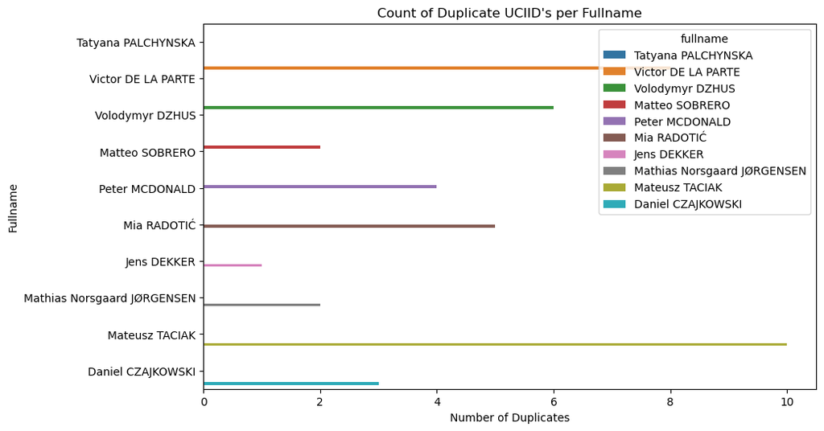

```python
#FILL IN - Inspecting the dataframe visually
df3 = df2[['First Name', 'Last Name','UCIID']].copy()
df3['fullname'] = df3['First Name'] + ' ' + df3['Last Name']

count_of_dupes = df3.groupby(['fullname'])['UCIID'].apply(lambda x: x.duplicated().sum()).reset_index(name='Duplicate Count')


# Plotting
plt.figure(figsize=(10, 6))
sns.barplot(x='Duplicate Count', y='fullname', hue='fullname', data=count_of_dupes.sample(10,random_state=42))
plt.title("Count of Duplicate UCIID's per Fullname")
plt.xlabel('Number of Duplicates')
plt.ylabel('Fullname')
plt.show()
```

```python
#FILL IN - Inspecting the dataframe programmatically

count_of_dupes.sample(10, random_state=42)
```

|  | fullname | Duplicate Count |
| --- | --- | --- |
| 13196 | Tatyana PALCHYNSKA | 0 |
| 13878 | Victor DE LA PARTE | 8 |
| 14008 | Volodymyr DZHUS | 6 |
| 9255 | Matteo SOBRERO | 2 |
| 11037 | Peter MCDONALD | 4 |
| 9525 | Mia RADOTIĆ | 5 |
| 6113 | Jens DEKKER | 1 |
| 9169 | Mathias Norsgaard JØRGENSEN | 2 |
| 9143 | Mateusz TACIAK | 10 |
| 2796 | Daniel CZAJKOWSKI | 3 |

```python
#FILL IN - Apply the cleaning strategy

# Keeping the most recent record, based on year
df2_sorted = df2.sort_values(by='Year', ascending=False)
df2_unique = df2_sorted.drop_duplicates(subset='UCIID', keep='first')
```

```python
#FILL IN - Validate the cleaning was successful

df2_unique.head()
```

|  | Year | Function | Last Name | First Name | Birth date | Birth date US | Age | Gender | Category | Country | Continent | Team Code | Team Name | UCIID |
| --- | --- | --- | --- | --- | --- | --- | --- | --- | --- | --- | --- | --- | --- | --- |
| 33732 | 2019 | Rider | VANHOUTTE | Fenna | 06/07/1997 | 7/6/1997 | 22 | Female | CTW | BEL | EUR | LSL | LOTTO SOUDAL LADIES | 10010969771 |
| 25389 | 2019 | Rider | BALDUCCI | Michela | 30/03/1995 | 3/30/1995 | 24 | Female | CTW | ITA | EUR | VAI | AROMITALIA - BASSO BIKES - VAIANO | 10009387257 |
| 25391 | 2019 | Rider | BEEKHUIS | Teuntje | 18/08/1995 | 8/18/1995 | 24 | Female | CTW | NED | EUR | BPC | BIEHLER PRO CYCLING | 10079063367 |
| 25392 | 2019 | Rider | BONDAR | Viktoriya | 25/09/1995 | 9/25/1995 | 24 | Female | CTW | UKR | EUR | LCW | LVIV CYCLING TEAM | 10009258531 |
| 25393 | 2019 | Rider | BRAAM | Danique | 05/09/1995 | 9/5/1995 | 24 | Female | CTW | NED | EUR | LSL | LOTTO SOUDAL LADIES | 10013775192 |

```python
df2_unique.duplicated().sum()
```

```
0
```

**Dropping the “duplicated” rows will make the overall analysis much cleaner. As mentioned before each rider can change team multiple times and this dataframe has simply recorded it**

**Looking at the date columns, both the "Birth Date" and "Birth Date US" are both "Object" data types, this is wrong.**

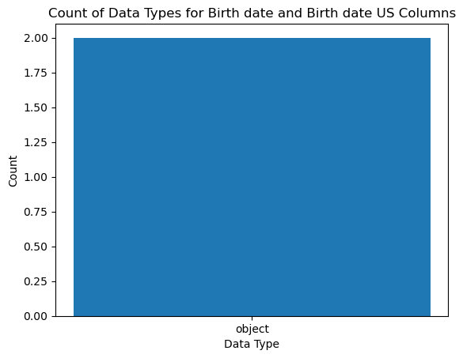

```python
#FILL IN - Inspecting the dataframe visually
dob_counts = df2_unique[['Birth date', 'Birth date US','UCIID']].copy()
data_types_counts = dob_counts[['Birth date', 'Birth date US']].dtypes.value_counts()

# Plotting the counts
plt.bar(data_types_counts.index.astype(str), data_types_counts.values)
plt.xlabel('Data Type')
plt.ylabel('Count')
plt.title('Count of Data Types for Birth date and Birth date US Columns')
plt.show()
```

```python
#FILL IN - Inspecting the dataframe programmatically
dob_counts = df2_unique[['Birth date', 'Birth date US','UCIID']].copy()
dob_counts.head()
```

|  | Birth date | Birth date US | UCIID |
| --- | --- | --- | --- |
| 33732 | 06/07/1997 | 7/6/1997 | 10010969771 |
| 25389 | 30/03/1995 | 3/30/1995 | 10009387257 |
| 25391 | 18/08/1995 | 8/18/1995 | 10079063367 |
| 25392 | 25/09/1995 | 9/25/1995 | 10009258531 |
| 25393 | 05/09/1995 | 9/5/1995 | 10013775192 |

```python
df2_unique[['Birth date', 'Birth date US']].info()
```

```
<class 'pandas.core.frame.DataFrame'>
Index: 14776 entries, 33732 to 10161
Data columns (total 2 columns):
 #   Column         Non-Null Count  Dtype
---  ------         --------------  -----
 0   Birth date     14776 non-null  object
 1   Birth date US  14776 non-null  object
dtypes: object(2)
memory usage: 346.3+ KB
```

```python
#FILL IN - Apply the cleaning strategy

df2_clean_dob = df2_unique.copy()
df2_clean_dob['dob'] = pd.to_datetime(df2_clean_dob['Birth date'], dayfirst=True)
df2_clean_dob.drop(columns =['Birth date','Birth date US'], inplace=True)
dob_new_pos = df2_clean_dob.pop('dob')
df2_clean_dob.insert(2,'dob', dob_new_pos)
```

```python
#FILL IN - Validate the cleaning was successful


df2_clean_dob.head()
```

|  | Year | Function | dob | Last Name | First Name | Age | Gender | Category | Country | Continent | Team Code | Team Name | UCIID |
| --- | --- | --- | --- | --- | --- | --- | --- | --- | --- | --- | --- | --- | --- |
| 33732 | 2019 | Rider | 1997-07-06 | VANHOUTTE | Fenna | 22 | Female | CTW | BEL | EUR | LSL | LOTTO SOUDAL LADIES | 10010969771 |
| 25389 | 2019 | Rider | 1995-03-30 | BALDUCCI | Michela | 24 | Female | CTW | ITA | EUR | VAI | AROMITALIA - BASSO BIKES - VAIANO | 10009387257 |
| 25391 | 2019 | Rider | 1995-08-18 | BEEKHUIS | Teuntje | 24 | Female | CTW | NED | EUR | BPC | BIEHLER PRO CYCLING | 10079063367 |
| 25392 | 2019 | Rider | 1995-09-25 | BONDAR | Viktoriya | 24 | Female | CTW | UKR | EUR | LCW | LVIV CYCLING TEAM | 10009258531 |
| 25393 | 2019 | Rider | 1995-09-05 | BRAAM | Danique | 24 | Female | CTW | NED | EUR | LSL | LOTTO SOUDAL LADIES | 10013775192 |

**This dataset is approximately 5 years old, and while it doesn't contain compeletly incorrect info, and this could be a issue that doesn’t necessarily impact the overall analysis, however I can use the D.O.B to pull the correct age for each rider by subtracting it from the current date.**

#### Creating the current age column

```python
#FILL IN - Apply the cleaning strategy

from datetime import datetime



current_year = datetime.now().year
df2_clean_dob['current_age'] = current_year - df2_clean_dob['dob'].dt.year
age_new_pos = df2_clean_dob.pop('Age')

cols = df2_clean_dob.columns.tolist()
cols.insert(1, cols.pop(cols.index('current_age')))
df2_clean_dob = df2_clean_dob.reindex(columns=cols)

#df2_clean_dob = df2_clean_dob.drop(columns='Age',axis=1).copy()
```

```python
#FILL IN - Validate the cleaning was successful


df2_clean_dob.head()
```

|  | Year | current_age | Function | dob | Last Name | First Name | Gender | Category | Country | Continent | Team Code | Team Name | UCIID |
| --- | --- | --- | --- | --- | --- | --- | --- | --- | --- | --- | --- | --- | --- |
| 33732 | 2019 | 27 | Rider | 1997-07-06 | VANHOUTTE | Fenna | Female | CTW | BEL | EUR | LSL | LOTTO SOUDAL LADIES | 10010969771 |
| 25389 | 2019 | 29 | Rider | 1995-03-30 | BALDUCCI | Michela | Female | CTW | ITA | EUR | VAI | AROMITALIA - BASSO BIKES - VAIANO | 10009387257 |
| 25391 | 2019 | 29 | Rider | 1995-08-18 | BEEKHUIS | Teuntje | Female | CTW | NED | EUR | BPC | BIEHLER PRO CYCLING | 10079063367 |
| 25392 | 2019 | 29 | Rider | 1995-09-25 | BONDAR | Viktoriya | Female | CTW | UKR | EUR | LCW | LVIV CYCLING TEAM | 10009258531 |
| 25393 | 2019 | 29 | Rider | 1995-09-05 | BRAAM | Danique | Female | CTW | NED | EUR | LSL | LOTTO SOUDAL LADIES | 10013775192 |

## Additional tidyness/quality issues

**Each column header is in proper case with a space, the first data file is in lowercase and uses and underscore.** **This will be updated to match the fist file**

**Finally, as with the first file, the female riders will be removed**

```python
#FILL IN - Apply the cleaning strategy

proper_names = {key: key.lower().replace(' ', '_') for key in ['Year', 'Function', 'Last Name', 'First Name',
                                                               'Gender', 'Category', 'Country', 'Continent', 'Team Code',
                                                               'Team Name', 'UCIID']}

df2_clean_dob.rename(columns=proper_names,inplace=True)


df2_cleaned = df2_clean_dob.loc[df2_clean_dob['gender'] == 'Male'].copy()
```

```python
#FILL IN - Validate the cleaning was successful
df2_clean_dob.head()
```

|  | year | current_age | function | dob | last_name | first_name | gender | category | country | continent | team_code | team_name | uciid |
| --- | --- | --- | --- | --- | --- | --- | --- | --- | --- | --- | --- | --- | --- |
| 33732 | 2019 | 27 | Rider | 1997-07-06 | VANHOUTTE | Fenna | Female | CTW | BEL | EUR | LSL | LOTTO SOUDAL LADIES | 10010969771 |
| 25389 | 2019 | 29 | Rider | 1995-03-30 | BALDUCCI | Michela | Female | CTW | ITA | EUR | VAI | AROMITALIA - BASSO BIKES - VAIANO | 10009387257 |
| 25391 | 2019 | 29 | Rider | 1995-08-18 | BEEKHUIS | Teuntje | Female | CTW | NED | EUR | BPC | BIEHLER PRO CYCLING | 10079063367 |
| 25392 | 2019 | 29 | Rider | 1995-09-25 | BONDAR | Viktoriya | Female | CTW | UKR | EUR | LCW | LVIV CYCLING TEAM | 10009258531 |
| 25393 | 2019 | 29 | Rider | 1995-09-05 | BRAAM | Danique | Female | CTW | NED | EUR | LSL | LOTTO SOUDAL LADIES | 10013775192 |

```python
#df2_clean_dob['gender'] = df2_clean_dob['gender'].astype('category')
df2_cleaned = df2_clean_dob.loc[df2_clean_dob['gender'] == 'Male'].copy()

df2_cleaned.info()
```

```
<class 'pandas.core.frame.DataFrame'>
Index: 12518 entries, 29546 to 10161
Data columns (total 13 columns):
 #   Column       Non-Null Count  Dtype
---  ------       --------------  -----
 0   year         12518 non-null  int64
 1   current_age  12518 non-null  int32
 2   function     12518 non-null  object
 3   dob          12518 non-null  datetime64[ns]
 4   last_name    12518 non-null  object
 5   first_name   12518 non-null  object
 6   gender       12518 non-null  object
 7   category     12518 non-null  object
 8   country      12518 non-null  object
 9   continent    12518 non-null  object
 10  team_code    12518 non-null  object
 11  team_name    12518 non-null  object
 12  uciid        12518 non-null  int64
dtypes: datetime64[ns](1), int32(1), int64(2), object(9)
memory usage: 1.3+ MB
```

**This file is now clean, the consistency of this file now matches that of the first. Lowercase headers and spaces have been removed.**

### **Remove unnecessary variables and combine datasets**

Depending on the datasets, you can also peform the combination before the cleaning steps.

```python
df1_cleaned.drop(columns=['country', 'gender'],inplace=True)
df2_cleaned.drop(columns=['year', 'gender','function','category','team_code', 'team_name'],axis=1,inplace=True)
```

```python
df1_cleaned.columns
```

```
Index(['fullname', 'first_name', 'last_name', 'one_day_race', 'giro_d_italia',
       'tour_de_france', 'la_vuelta_ciclista_a_españa', 'stage_races',
       'mountain_bike', 'cyclo_cross', 'indoor', 'track', 'road', 'junior',
       'u_23', 'elite', 'masters', 'individual_time_trial', 'team_time_trial',
       'team_time_trial_mixed_relay', 'olympic', 'world_championships',
       'continental_championships', 'national_championships', 'DSQ', 'DNF',
       'DNS'],
      dtype='object')
```

```python
df2_cleaned.columns
```

```
Index(['current_age', 'dob', 'last_name', 'first_name', 'country', 'continent',
       'uciid'],
      dtype='object')
```

```python
df1_cleaned.sample(5)
```

|  | fullname | first_name | last_name | one_day_race | giro_d_italia | tour_de_france | la_vuelta_ciclista_a_españa | stage_races | mountain_bike | cyclo_cross | ... | individual_time_trial | team_time_trial | team_time_trial_mixed_relay | olympic | world_championships | continental_championships | national_championships | DSQ | DNF | DNS |
| --- | --- | --- | --- | --- | --- | --- | --- | --- | --- | --- | --- | --- | --- | --- | --- | --- | --- | --- | --- | --- | --- |
| 43568 | Gianluca SIMIONI | Gianluca | SIMIONI | 0 | 0 | 0 | 0 | 0 | False | True | ... | 0 | 0 | 0 | 0 | 0 | 0 | 0 | 0 | 0 | 0 |
| 41262 | Friso ROSCAM ABBING | Friso | ROSCAM ABBING | 0 | 0 | 0 | 0 | 0 | False | False | ... | 0 | 0 | 0 | 0 | 0 | 0 | 0 | 0 | 0 | 0 |
| 108009 | Rémi LELANDAIS | Rémi | LELANDAIS | 0 | 0 | 0 | 0 | 0 | False | True | ... | 0 | 1 | 0 | 0 | 0 | 0 | 1 | 0 | 1 | 0 |
| 35296 | Erasmo MALDONADO ROJAS | Erasmo | MALDONADO ROJAS | 0 | 0 | 0 | 0 | 0 | False | False | ... | 0 | 0 | 0 | 0 | 0 | 0 | 0 | 0 | 0 | 0 |
| 42128 | Ganzorig BAT-ORSHIKH | Ganzorig | BAT-ORSHIKH | 0 | 0 | 0 | 0 | 0 | False | False | ... | 0 | 0 | 0 | 0 | 0 | 0 | 0 | 0 | 0 | 0 |

5 rows × 27 columns

```python
df2_cleaned.sample(5)
```

|  | current_age | dob | last_name | first_name | country | continent | uciid |
| --- | --- | --- | --- | --- | --- | --- | --- |
| 9181 | 42 | 1982-03-20 | CUPITT | Michael | AUS | OCE | 10007622362 |
| 11597 | 43 | 1981-02-03 | BROUZES | Niels | FRA | EUR | 10002347279 |
| 27933 | 37 | 1987-11-06 | ZANINOVIC | Vinko | CRO | EUR | 10003271813 |
| 31783 | 35 | 1989-01-07 | RUIZ PINTO | Eloy | ESP | EUR | 10007574569 |
| 38940 | 30 | 1994-01-27 | SCHULTUS | Patrick | AUT | EUR | 10008653491 |

```python
merged_dfs = pd.merge(df1_cleaned, df2_cleaned, on=['first_name','last_name'], how='inner')
merged_dfs.head()
```

|  | fullname | first_name | last_name | one_day_race | giro_d_italia | tour_de_france | la_vuelta_ciclista_a_españa | stage_races | mountain_bike | cyclo_cross | ... | continental_championships | national_championships | DSQ | DNF | DNS | current_age | dob | country | continent | uciid |
| --- | --- | --- | --- | --- | --- | --- | --- | --- | --- | --- | --- | --- | --- | --- | --- | --- | --- | --- | --- | --- | --- |
| 0 | Aaron DONNELLY | Aaron | DONNELLY | 0 | 0 | 0 | 0 | 0 | False | False | ... | 2 | 0 | 0 | 0 | 0 | 33 | 1991-02-27 | AUS | OCE | 10006178779 |
| 1 | Aaron GATE | Aaron | GATE | 0 | 0 | 0 | 0 | 0 | False | False | ... | 18 | 21 | 0 | 1 | 0 | 34 | 1990-11-26 | NZL | OCE | 10004405501 |
| 2 | Aaron GROSSER | Aaron | GROSSER | 0 | 0 | 0 | 0 | 0 | False | False | ... | 0 | 4 | 0 | 2 | 0 | 28 | 1996-10-06 | GER | EUR | 10009082618 |
| 3 | Aaron KEARNEY | Aaron | KEARNEY | 0 | 0 | 0 | 0 | 0 | False | False | ... | 0 | 0 | 0 | 0 | 0 | 26 | 1998-12-27 | IRL | EUR | 10015837353 |
| 4 | Aaron KEMPS | Aaron | KEMPS | 0 | 0 | 0 | 0 | 0 | False | False | ... | 0 | 0 | 0 | 0 | 0 | 41 | 1983-09-10 | AUS | OCE | 10002839555 |

5 rows × 32 columns

```python
merged_dfs.shape
```

```
(9045, 32)
```

```python
merged_dfs.info()
```

```
<class 'pandas.core.frame.DataFrame'>
RangeIndex: 9045 entries, 0 to 9044
Data columns (total 32 columns):
 #   Column                       Non-Null Count  Dtype
---  ------                       --------------  -----
 0   fullname                     9045 non-null   object
 1   first_name                   9045 non-null   object
 2   last_name                    9045 non-null   object
 3   one_day_race                 9045 non-null   int32
 4   giro_d_italia                9045 non-null   int32
 5   tour_de_france               9045 non-null   int32
 6   la_vuelta_ciclista_a_españa  9045 non-null   int32
 7   stage_races                  9045 non-null   int32
 8   mountain_bike                9045 non-null   bool
 9   cyclo_cross                  9045 non-null   bool
```

[output cut: 24 more lines]

```python
merged_dfs.cyclo_cross.value_counts()
```

```
cyclo_cross
False    7783
True     1262
Name: count, dtype: int64
```

```python
df1_cleaned.head()
```

|  | fullname | first_name | last_name | one_day_race | giro_d_italia | tour_de_france | la_vuelta_ciclista_a_españa | stage_races | mountain_bike | cyclo_cross | ... | individual_time_trial | team_time_trial | team_time_trial_mixed_relay | olympic | world_championships | continental_championships | national_championships | DSQ | DNF | DNS |
| --- | --- | --- | --- | --- | --- | --- | --- | --- | --- | --- | --- | --- | --- | --- | --- | --- | --- | --- | --- | --- | --- |
| 0 | - DUKUZUMUREMYI | - | DUKUZUMUREMYI | 0 | 0 | 0 | 0 | 0 | False | False | ... | 0 | 0 | 0 | 0 | 0 | 0 | 0 | 0 | 0 | 0 |
| 2 | - UWIDUHAYE | - | UWIDUHAYE | 0 | 0 | 0 | 0 | 0 | False | False | ... | 0 | 0 | 0 | 0 | 0 | 0 | 0 | 0 | 0 | 0 |
| 4 | : Willam RODRIGUEZ CUELLAR | : Willam | RODRIGUEZ CUELLAR | 0 | 0 | 0 | 0 | 0 | False | False | ... | 0 | 0 | 0 | 0 | 0 | 0 | 2 | 0 | 0 | 0 |
| 10 | ADRIANO SANCHES GROFF | ADRIANO | SANCHES GROFF | 0 | 0 | 0 | 0 | 0 | False | False | ... | 0 | 0 | 0 | 0 | 0 | 0 | 0 | 0 | 0 | 0 |
| 12 | AHMED EL AHOUEL | AHMED | EL AHOUEL | 0 | 0 | 0 | 0 | 0 | False | False | ... | 0 | 0 | 0 | 0 | 0 | 0 | 0 | 0 | 0 | 0 |

5 rows × 27 columns

## 4. Update your data store

Update your local database/data store with the cleaned data, following best practices for storing your cleaned data:

- Must maintain different instances / versions of data (raw and cleaned data)
- Must name the dataset files informatively
- Ensure both the raw and cleaned data is saved to your database/data store

The short version of the requirement is: Save a copy of your cleaned data (use a different name for the file so that you do not over-write the original) in the same location as the original data (usually the folder that contains the notebook).

```python
#FILL IN - saving data
merged_dfs.to_csv('UCI_mens_cycling_v1.csv')
df1_cleaned.to_csv('uci_race_results_clean.csv')
df2_cleaned.to_csv('uci_riders_bio_data_clean.csv')
```

## 5. Answer the research question

### **5.1:** Are multi-disciplined professional cyclists more successful the single discipline cyclists?

**We will take a look at two grouped race types, "Road" (can be Grand Tours, multi-stage, One Day, Championship) and Time Trials – often called the “Race of Truth”, in cycling this type of race pits each rider against the clock. Whoever crosses the line with the fastest time wins (a full breakdown can be found here: https://en.wikipedia.org/wiki/Individual_time_trial). And will try to find out which party has had more success; this is measured by the number of podium places.**

```python
# Importing the data
```

```python
data = pd.read_csv('UCI_mens_cycling_v1', index_col=None)
df = data.drop(columns=['Unnamed: 0']).copy()
```

```python
columns_to_check = ['cyclo_cross', 'mountain_bike', 'indoor', 'track']
single_disp = df.loc[~df[columns_to_check].any(axis=1)]
multi_disp = df.loc[df[columns_to_check].any(axis=1)]

assert set(single_disp.index).isdisjoint(set(multi_disp.index))
```

**The above code breaks the data into the two aforementioned parties, Single Discipline and Multi-Discipline**

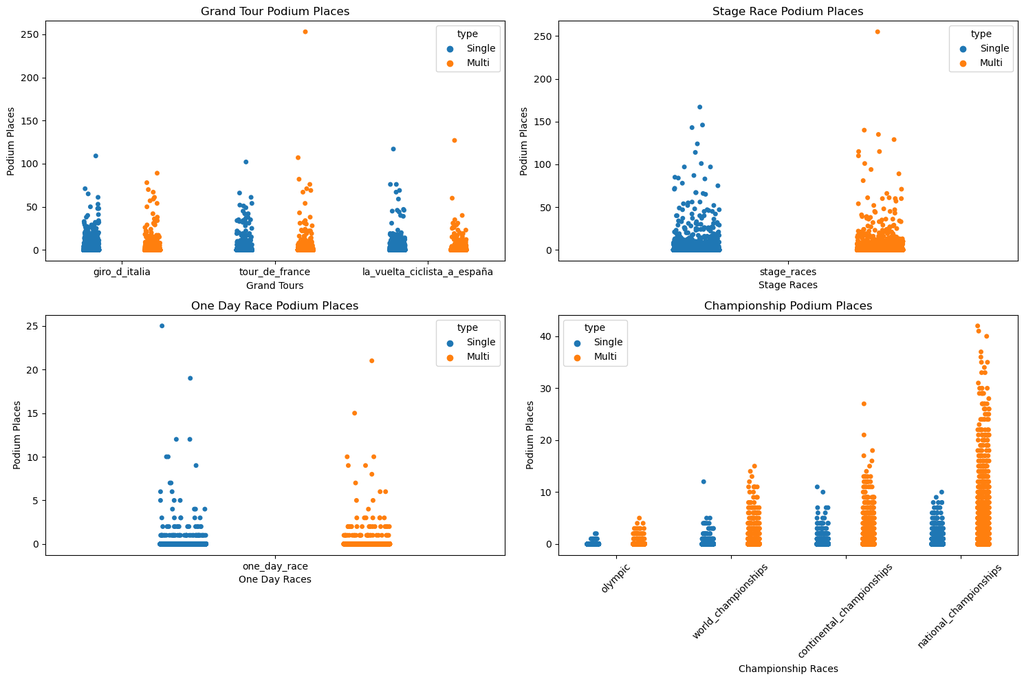

```python
#Visual 1 - FILL IN

single_disp.loc[:, 'type'] = 'Single'
multi_disp.loc[:, 'type'] = 'Multi'

# Concatenate the data
combined_data = pd.concat([single_disp, multi_disp])

# Create the plots
fig, axes = plt.subplots(2, 2, figsize=(15, 10))

colors = sns.color_palette("tab20", 2)

# Plot 1: Grand Tours
melted_data = combined_data.melt(id_vars=['type'],
                                 value_vars=['giro_d_italia', 'tour_de_france', 'la_vuelta_ciclista_a_españa'],
                                 var_name='Tour', value_name='Podium Places')
sns.stripplot(data=melted_data, x='Tour', y='Podium Places', hue='type', dodge=True, jitter=True, ax=axes[0, 0])
axes[0, 0].set_title('Grand Tour Podium Places')
axes[0, 0].set_xlabel('Grand Tours')
axes[0, 0].set_ylabel('Podium Places')

# Plot 2: Stage Races
melted_data = combined_data.melt(id_vars=['type'], value_vars=['stage_races'],
                                 var_name='Stage_Races', value_name='Podium Places')
sns.stripplot(data=melted_data, x='Stage_Races', y='Podium Places', hue='type', dodge=True, jitter=True, ax=axes[0, 1])
axes[0, 1].set_title('Stage Race Podium Places')
axes[0, 1].set_xlabel('Stage Races')
axes[0, 1].set_ylabel('Podium Places')

# Plot 3: One Day Races
melted_data = combined_data.melt(id_vars=['type'], value_vars=['one_day_race'],
                                 var_name='One_Day_Races', value_name='Podium Places')
sns.stripplot(data=melted_data, x='One_Day_Races', y='Podium Places', hue='type', dodge=True, jitter=True, ax=axes[1, 0])
axes[1, 0].set_title('One Day Race Podium Places')
axes[1, 0].set_xlabel('One Day Races')
axes[1, 0].set_ylabel('Podium Places')

# Plot 4: Championships
melted_data = combined_data.melt(id_vars=['type'],
                                 value_vars=['olympic', 'world_championships', 'continental_championships', 'national_championships'],
                                 var_name='Championship', value_name='Podium Places')
sns.stripplot(data=melted_data, x='Championship', y='Podium Places', hue='type', dodge=True, jitter=True, ax=axes[1, 1])
axes[1, 1].set_title('Championship Podium Places')
axes[1, 1].set_xlabel('Championship Races')
axes[1, 1].set_ylabel('Podium Places')

plt.xticks(rotation=45)
plt.tight_layout()
plt.show()
```

**With the exception of the “Championship Races”, it’s difficult to say with any kind of certainty (apart from a few outliers), that either party, single or multi, show a clear winner. However, for Championship races multi-disciplined riders fair much better**

### Time Trials

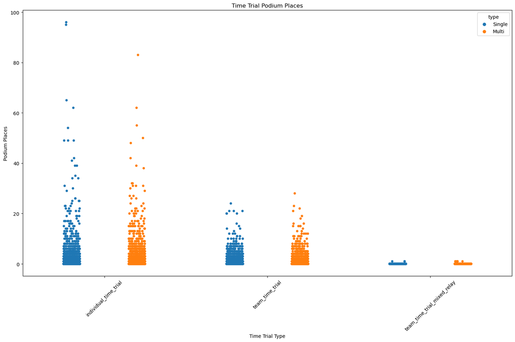

```python
#Visual 2 - FILL IN

# Set the type for each DataFrame
single_disp.loc[:, 'type'] = 'Single'
multi_disp.loc[:, 'type'] = 'Multi'

# Concatenate the data
combined_data = pd.concat([single_disp, multi_disp])

# Create the plot
fig, ax = plt.subplots(figsize=(15, 10))

colors = sns.color_palette("tab20", 2)

# Melt the data for the time trials
melted_data = combined_data.melt(id_vars=['type'],
                                 value_vars=['individual_time_trial', 'team_time_trial', 'team_time_trial_mixed_relay'],
                                 var_name='Time_Trails', value_name='Podium Places')

# Plot the data
sns.stripplot(data=melted_data, x='Time_Trails', y='Podium Places', hue='type', dodge=True, jitter=True, ax=ax)
ax.set_title('Time Trial Podium Places')
ax.set_xlabel('Time Trial Type')
ax.set_ylabel('Podium Places')

plt.xticks(rotation=45)
plt.tight_layout()
plt.show()
```

**Looking at Time Trials, again we can see that both disciplines are very close, with the slight edge being given to single discipline riders in “Individual Time Trial” (ITT), while “Team Time Trial” (TTT) goes to multi disciplined riders, but not by much.**

### Overall

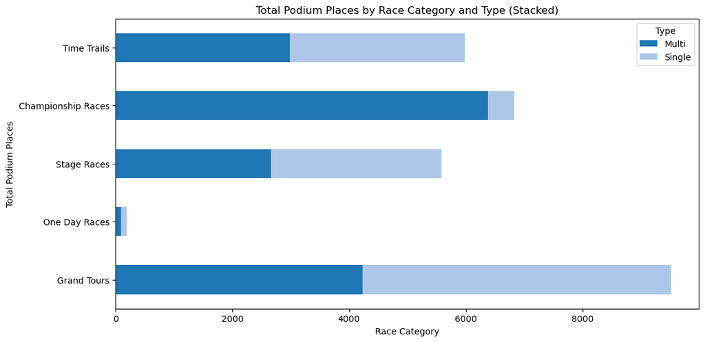

```python
#Visual 3 - FILL IN

single_disp_totals = single_disp[['type','one_day_race', 'giro_d_italia',
                                        'tour_de_france', 'la_vuelta_ciclista_a_españa', 'stage_races',
                                        'olympic', 'world_championships','continental_championships', 'national_championships',
                                  'individual_time_trial', 'team_time_trial','team_time_trial_mixed_relay'
                                        ]]
multi_disp_totals = multi_disp[['type','one_day_race', 'giro_d_italia',
                                        'tour_de_france', 'la_vuelta_ciclista_a_españa', 'stage_races',
                                        'olympic', 'world_championships','continental_championships', 'national_championships',
                                'individual_time_trial', 'team_time_trial','team_time_trial_mixed_relay'
                                        ]]


combined_totals = pd.concat([single_disp_totals, multi_disp_totals])
combined_totals.reset_index(drop=True, inplace=True)



combined_totals[['type','giro_d_italia', 'tour_de_france','la_vuelta_ciclista_a_españa'
                              ]].groupby(['type','giro_d_italia','tour_de_france', 'la_vuelta_ciclista_a_españa']).sum()

grand_tours = combined_totals[['type','giro_d_italia', 'tour_de_france','la_vuelta_ciclista_a_españa'
                              ]].groupby(['type','giro_d_italia','tour_de_france', 'la_vuelta_ciclista_a_españa']).sum().reset_index()

stage_races = combined_totals[['type','stage_races'
                              ]].groupby(['type','stage_races']).sum().reset_index()

one_day_races = combined_totals[['type','one_day_race'
                              ]].groupby(['type','one_day_race']).sum().reset_index()

championship_races = combined_totals[['type','olympic', 'world_championships','continental_championships', 'national_championships'
                              ]].groupby(['type','olympic', 'world_championships','continental_championships', 'national_championships']).sum().reset_index()

time_trail = combined_totals[['type','individual_time_trial', 'team_time_trial','team_time_trial_mixed_relay'
                             ]].groupby(['type','individual_time_trial', 'team_time_trial','team_time_trial_mixed_relay']
                                       ).sum().reset_index()


# Create the 'total_podium_places' column for each category
grand_tours['total_podium_places'] = grand_tours[['giro_d_italia', 'tour_de_france', 'la_vuelta_ciclista_a_españa']].sum(axis=1)
one_day_races['total_podium_places'] = one_day_races['one_day_race']
stage_races['total_podium_places'] = stage_races['stage_races']
championship_races['total_podium_places'] = championship_races[['olympic', 'world_championships',
                                                                'continental_championships', 'national_championships']].sum(axis=1)
time_trail['total_podium_places'] = time_trail[['individual_time_trial', 'team_time_trial','team_time_trial_mixed_relay']].sum(axis=1)


# Group by 'type' and sum the 'total_podium_places'
grand_tour_totals = grand_tours.groupby('type')['total_podium_places'].sum()
one_day_race_totals = one_day_races.groupby('type')['total_podium_places'].sum()
stage_race_totals = stage_races.groupby('type')['total_podium_places'].sum()
championship_race_totals = championship_races.groupby('type')['total_podium_places'].sum()
time_trail_totals = time_trail.groupby('type')['total_podium_places'].sum()

overall_results = pd.DataFrame({
 'Category': ['Grand Tours', 'One Day Races', 'Stage Races', 'Championship Races', 'Time Trails'],
    'Multi': [grand_tour_totals['Multi'], one_day_race_totals['Multi'], stage_race_totals['Multi'], championship_race_totals['Multi'], time_trail_totals['Multi']],
    'Single': [grand_tour_totals['Single'], one_day_race_totals['Single'], stage_race_totals['Single'], championship_race_totals['Single'], time_trail_totals['Single']]

})

colors = sns.color_palette("tab20", 2)

fig, ax = plt.subplots(figsize=(12, 6))



overall_results.set_index('Category').plot(kind='barh', stacked=True, ax=ax, color=colors)
plt.title('Total Podium Places by Race Category and Type (Stacked)')
plt.ylabel('Total Podium Places')
plt.xlabel('Race Category')
plt.legend(title='Type')
plt.show();
```

**Here we have a clearer picture of the success rates for all race types, and aside from Championship races, it’s difficult to say if/which group is stronger.**

### **5.2:** Reflection

In 2-4 sentences, if you had more time to complete the project, what actions would you take? For example, which data quality and structural issues would you look into further, and what research questions would you further explore?

*Answer:* FILL IN These datasets are missing a lot of data, unfortunately (as mentioned) UCI datasets are rare and hard to find, especially when it comes to women’s racing. I would like to have reached out to the UCI for more information about the riders/results/competition. The website Pro Cycling Stats: https://www.procyclingstats.com/index.php does have much more comprehensive data, however while I can scrape the race data, it’s not centralised. For example, all of the races are on separate pages depending on the year, coupled with the fact that each rider also has their own page. It would take a considerable amount of time to collate all of the necessary data to complete this task.  
It would’ve been interesting to see if there’s a difference in terms of single/multi disciplined male and female pro cyclists’ results However as an avid cycling fan I might take this on as a personal project.

```python
!jupyter nbconvert --to pdf "Project Practice.ipynb"
```

[output not shown]

[output cut: 17 more lines]

[output not shown]